# Cardio Good Fitness Project

## Multivariate analysis focusing on individual products with variables of interest

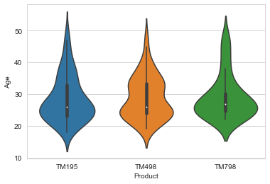

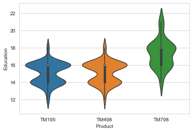

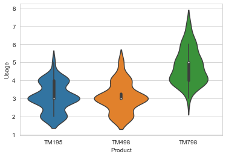

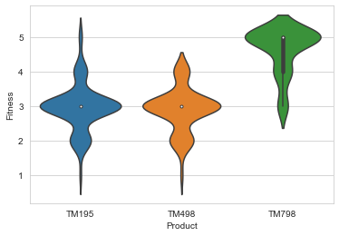

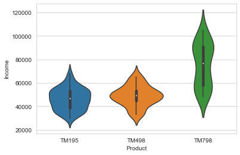

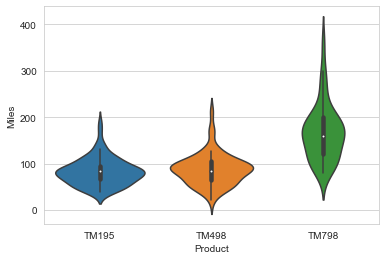

```python
for t in data_num_sansout.columns:
    sns.violinplot(data=raw_data,x='Product',y=t)
    plt.show()
```

There seems to be a pattern emerging. Grouping variables might elucidate further:

```python
[print(raw_data.groupby(['Product',t])[t].count()) for t in ['Gender','MaritalStatus']]
```

```
Product  Gender
TM195    Female    40
         Male      40
TM498    Female    29
         Male      31
TM798    Female     7
         Male      33
Name: Gender, dtype: int64
Product  MaritalStatus
TM195    Partnered        48
         Single           32
TM498    Partnered        36
         Single           24
TM798    Partnered        23
         Single           17
Name: MaritalStatus, dtype: int64
```

```
[None, None]
```

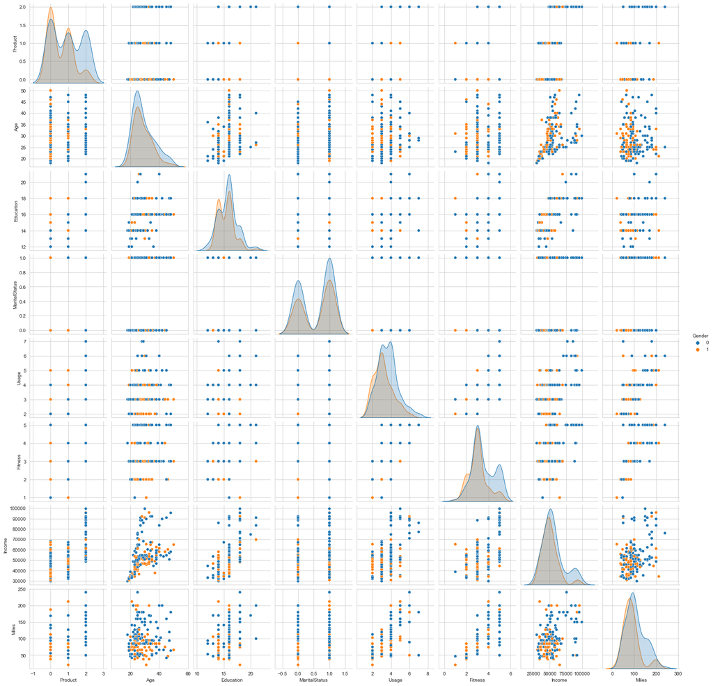

```python
sns.pairplot(data_manip, hue="Gender")
```

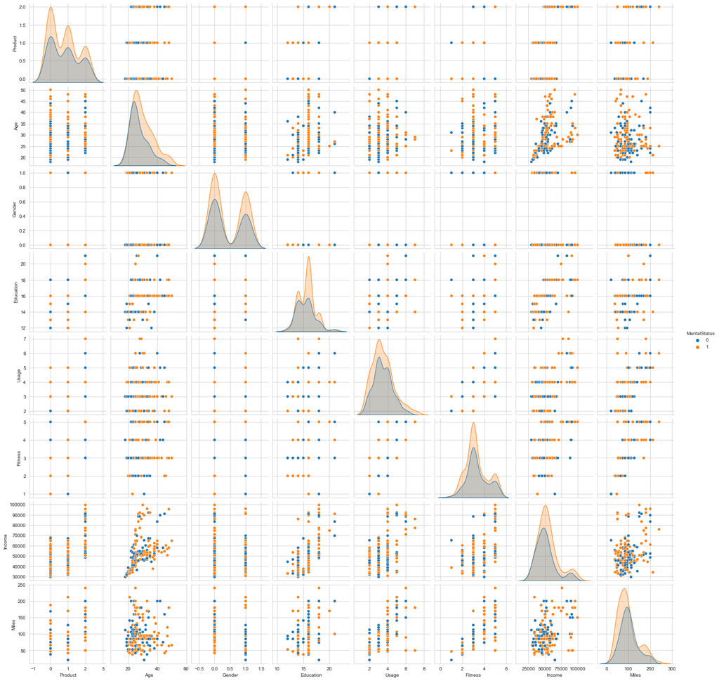

```python
sns.pairplot(data_manip, hue="MaritalStatus")
```

There do not seem to be any strong/general clustering in the correlations between the variables when separated by Gender or Marital Status. Looking in more detail:

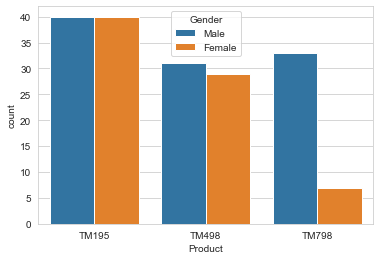

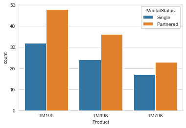

```python
for t in ['Gender','MaritalStatus']:
    sns.countplot(data=raw_data,x='Product',hue=t)
    plt.show()
```

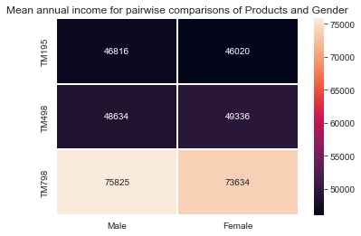

```python
gender = raw_data['Gender'].unique()
product = raw_data['Product'].unique()
pgi = pd.DataFrame(columns=gender,index = product,dtype='float')
for g in gender:
    for p in product:
        value = raw_data[(raw_data['Product']==p)&(raw_data['Gender']==g)]['Income'].mean()
        pgi.at[p,g]=value

sns.heatmap(pgi,annot=True,fmt=".0f",linewidths=0.3)
plt.title('Mean annual income for pairwise comparisons of\n Products and Gender')
```

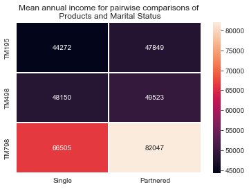

```python
mstatus = raw_data['MaritalStatus'].unique()
product = raw_data['Product'].unique()
pmi = pd.DataFrame(columns=mstatus,index = product,dtype='float')
for m in mstatus:
    for p in product:
        value = raw_data[(raw_data['Product']==p)&(raw_data['MaritalStatus']==m)]['Income'].mean()
        pmi.at[p,m]=value
sns.heatmap(pmi,annot=True,fmt=".0f",linewidths=0.3)
plt.title('Mean annual income for pairwise comparisons of\n Products and Marital Status')
```

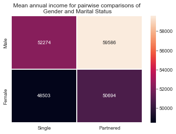

```python
mstatus = raw_data['MaritalStatus'].unique()
gender = raw_data['Gender'].unique()
gmi = pd.DataFrame(columns=mstatus,index = gender,dtype='float')
for m in mstatus:
    for g in gender:
        value = raw_data[(raw_data['Gender']==g)&(raw_data['MaritalStatus']==m)]['Income'].mean()
        gmi.at[g,m]=value
sns.heatmap(gmi,annot=True,fmt=".0f",linewidths=0.3)
plt.title('Mean annual income for pairwise comparisons of\n Gender and Marital Status')
```

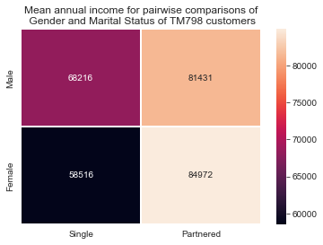

```python
mstatus = raw_data['MaritalStatus'].unique()
gender = raw_data['Gender'].unique()
gmi = pd.DataFrame(columns=mstatus,index = gender,dtype='float')
for m in mstatus:
    for g in gender:
        value = raw_data[(raw_data['Gender']==g)&(raw_data['MaritalStatus']==m)&(raw_data['Product']=='TM798')]['Income'].mean()
        gmi.at[g,m]=value
sns.heatmap(gmi,annot=True,fmt=".0f",linewidths=0.3)
plt.title('Mean annual income for pairwise comparisons of\n Gender and Marital Status of TM798 customers')
```

## Take-aways

#### Analysis of customer base:

Their market seems to primarily consist of young adults (20-30 years old) with generally median incomes (~50k) who are looking to have a generally healthy lifestyle within relationships. The latter statement was based on a reported usage of 2, 3 or 4 days out of the week for around 85% of users, which correlated to an average self-evaluation score of 3 out of 5 for more than half of the users. However, when looking at their three products certain patterns emerge that are worth looking into closely. Their TM798 model seems to be their least selling item (accounting for around only a fifth of total sales) yet it is preferred by the users that rated themselves highest on fitness as well as the highest expectation of usage. Furthermore, if I had to guess this product would seem to be the most expensive model, given that its rate of purchase coincides with users with the highest income. To reaffirm that this indication was not coincidental with other parameters that affect income, a multivariate analysis was also performed with gender and marital status (age was removed from this analysis as for all three products, customers were primarily young). While there were some minor fluctuations in mean income for genders and marital status, highest incomes for either gender or marital status gravitated mostly to the third product.

Furthermore, it is telling that this product is also more popular with users with the highest level of education. This means that they would most likely do due diligence to research to product when deciding to invest. Given that most of their customers earn median income, I don’t suspect that customers are drawn to the brand by luxury, but rather by quality. This type of customer behavior would imply that this product pertains to a notable brand who is known for quality performance, but customers are looking for a deal since their expectation of usage may not warrant the investment for the flagship product (which I assume is the TM798).